# Prob 5 CP 2

15 de junho de 2016

# Análise do efeito da beleza na pontuação média da didática dos professores

De posse desses dados, queremos avaliar se a beleza possui um efeito significativo no score dos professores, levando em conta os demais fatores que foram identificados como tento possíveis efeitos, que são as variáveis rank, ethnicity, gender, language, age, cls_*, pic_outfit e pic_color. Para isso faça o seguinte:

1. Comece a análise como se começa toda análise: faça um descritivo

## Análise dos dados

A partir do conjunto de dados fornecido, serão analisadas as seguintes variáveis para responder as perguntas:

- **score**: Pontuação média na avaliação docente
- **bty_avg**: Média de beleza dos professores
- **gender**: Sexo dos professores
- **ethnicity**: Etnia dos professores

Foram escolhidos duas variáveis além das solicitadas que podem influenciar em conjunto com a beleza na pontuação dos professores.

Nossa hipótese é que o sexo e etnia dos professores influenciam no efeito que a beleza tem sob a pontuação. Mas antes ver algumas informações sobre os dados.

```r
eval_df <- eval %>% select(score, bty_avg, gender, ethnicity)
summary (eval_df)
```

```
     score          bty_avg         gender           ethnicity
 Min.   :2.300   Min.   :1.667   female:195   minority    : 64
 1st Qu.:3.800   1st Qu.:3.167   male  :268   not minority:399
 Median :4.300   Median :4.333
 Mean   :4.175   Mean   :4.418
 3rd Qu.:4.600   3rd Qu.:5.500
 Max.   :5.000   Max.   :8.167
```

Podemos perceber que existem mais professores do sexo masculino na nossa amostra, além de termos poucos professores que representam a minoria etnica, o que já era esperado. Vamos analisar com mais detalhes as variáveis score e beleza média.

Abaixo temos dois gráficos onde podemos visualizar a distribuição das variáveis pontuação e beleza. É bem evidente a diferença entre como os professores são avaliados pelas suas capacidades e como são avaliados pela sua beleza.

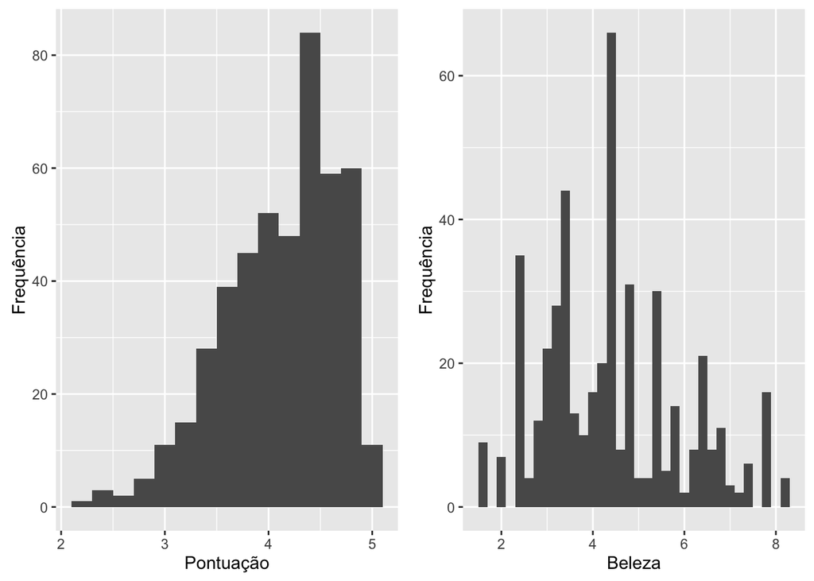

```r
gridExtra::grid.arrange(
  ggplot(eval_df, aes(x=score)) +
  geom_histogram(binwidth = 0.2) +
  xlab("Pontuação") +
  ylab("Frequência"),
ggplot(eval_df, aes(x=bty_avg)) +
  geom_histogram(binwidth = 0.2) +
  xlab("Beleza") +
  ylab("Frequência"),
ncol = 2
)
```

Logo, isso indica que há pouca chance de se ter um efeito forte da beleza sob a pontuação dos professores. A seguir iremos aplicar regressão linear para entender melhor essa relação.

## Relação entre Beleza e Score

Para explicar o efeito que a beleza exerce sobre o score, definimos o seguinte modelo:

$$\hat{score}=B_0+B_1 \cdot bty\_avg$$

Abaixo podemos ver o efeito que a beleza exerce sob a pontuação do professor.

```r
eval_simples <- eval %>% select(score, bty_avg)
modelEval <- lm(score ~ bty_avg, data = eval_simples)

confint(modelEval)
```

```
                 2.5 %     97.5 %
(Intercept) 3.73070764 4.02996827
bty_avg     0.03462292 0.09865116
```

```r
summary(modelEval)
```

```
Call:
lm(formula = score ~ bty_avg, data = eval_simples)

Residuals:
    Min      1Q  Median      3Q     Max
-1.9246 -0.3690  0.1420  0.3977  0.9309

Coefficients:
            Estimate Std. Error t value Pr(>|t|)
(Intercept)  3.88034    0.07614   50.96  < 2e-16 ***
bty_avg      0.06664    0.01629    4.09 5.08e-05 ***
---
Signif. codes:  0 '***' 0.001 '**' 0.01 '*' 0.05 '.' 0.1 ' ' 1

Residual standard error: 0.5348 on 461 degrees of freedom
Multiple R-squared:  0.03502,   Adjusted R-squared:  0.03293
F-statistic: 16.73 on 1 and 461 DF,  p-value: 5.083e-05
```

Como podemos ver acima, temos o *R-squared* com cerca de 3%, o que explica muito pouco sobre o efeito da beleza na pontuação dos professores. Abaixo é possível perceber que os pressupostos da regressão linear foram atendidos. Temos poucos *outliers* e os residuos se comportam como esperado.

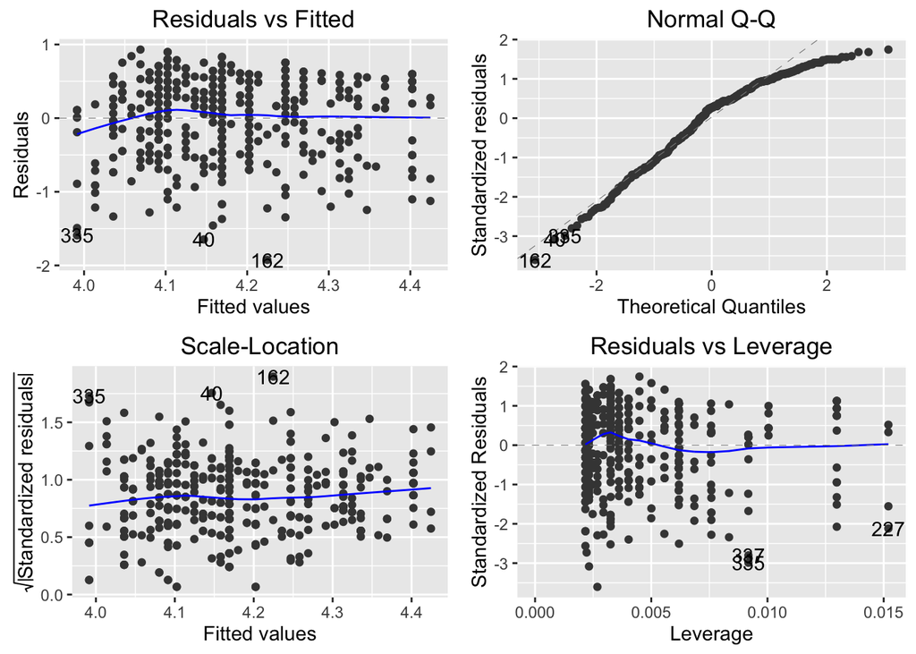

```r
autoplot(modelEval)
```

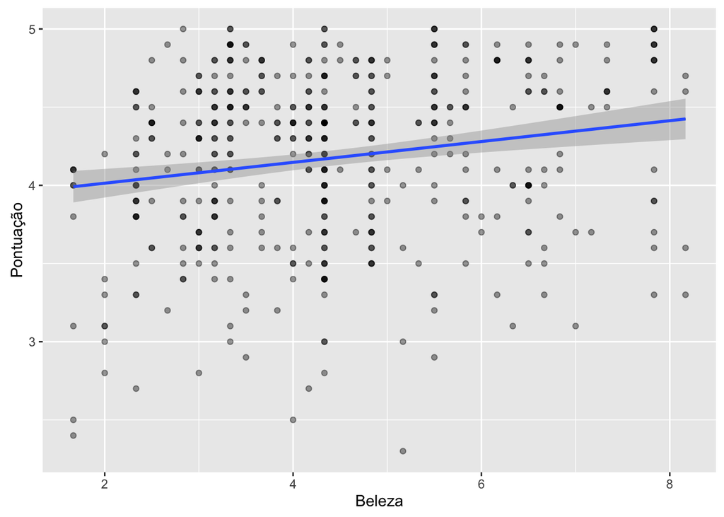

```r
ggplot(eval_simples, aes(x = bty_avg, y = score)) +
  geom_point(alpha = 0.4) +
  geom_line(aes(y = predict(modelEval, eval_simples))) +
  stat_smooth(method = "lm") +
  xlab("Beleza") +
  ylab("Pontuação")
```

## Influência de outras variáveis

Agora será analisado a influência das variáveis etnia e genero no efeito que a beleza exerce sob o score.

Nosso modelo provavelmente irá aplicar o sexo masculino na variável de genero como visto em sala de aula. Acredito que essa variável terá uma influência positiva sobre os efeitos da beleza, bem como a variável de etnia também terá efeito positivo sobre o modelo. Esse modelo é definido por:

$$\hat{score}=B_0+B_1 \cdot bty\_avg+B_2 \cdot gender +B_3 \cdot ethnicity$$

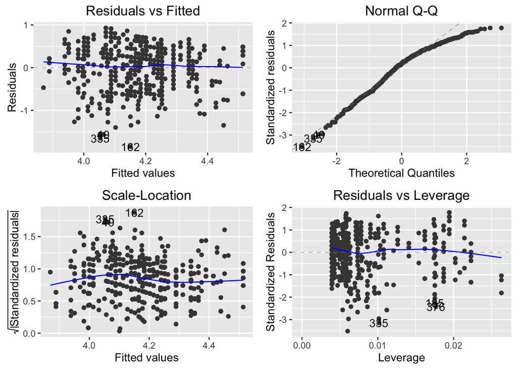

```r
bty_df <- eval %>% select(score, gender, ethnicity, bty_avg)

model_bty <- lm(score ~ bty_avg + gender + ethnicity, data = bty_df)
autoplot(model_bty)
```

Os pressupostos necessários para satisfazer a regressão linear parecem estar dentro do esperado. Poucos *outliers* e os residuos tem uma distribuição semelhante a normal.

Agora vamos verificar os efeitos das variáveis no modelo. A partir do sumário desse modelo, é possível afirmar que houve uma melhora no efeito das variáveis adicionadas em relação a pontuação. Temos o *R-squared* com cerca de 6% e também houve um acréscimo no efeito da beleza sobre o score.

```r
summary(model_bty)
```

```
Call:
lm(formula = score ~ bty_avg + gender + ethnicity, data = bty_df)

Residuals:
    Min      1Q  Median      3Q     Max
-1.8504 -0.3669  0.1104  0.4107  0.9287

Coefficients:
                      Estimate Std. Error t value Pr(>|t|)
(Intercept)            3.65789    0.10388  35.212  < 2e-16 ***
bty_avg                0.07479    0.01624   4.606 5.32e-06 ***
gendermale             0.16415    0.05046   3.253  0.00123 **
ethnicitynot minority  0.10609    0.07159   1.482  0.13906
---
Signif. codes:  0 '***' 0.001 '**' 0.01 '*' 0.05 '.' 0.1 ' ' 1

Residual standard error: 0.528 on 459 degrees of freedom
Multiple R-squared:  0.0636,    Adjusted R-squared:  0.05748
F-statistic: 10.39 on 3 and 459 DF,  p-value: 1.255e-06
```

Porém, percebemos que o intervalo de confiança da variável *ethnicity* passa pelo zero, isso quer dizer que essa variável não exerce nenhum efeito em nosso modelo. Portanto, ela será descartada.

```r
confint(model_bty)
```

```
                            2.5 %    97.5 %
(Intercept)            3.45374105 3.8620322
bty_avg                0.04288023 0.1066951
gendermale             0.06498371 0.2633181
ethnicitynot minority -0.03459934 0.2467832
```

Dessa forma, temos o seguinte modelo ajustado:
$$\hat{score}=B_0+B_1 \cdot bty\_avg+B_2 \cdot gender$$

```r
model_bty <- lm(score ~ bty_avg + gender, data = bty_df)
summary(model_bty)
```

```
Call:
lm(formula = score ~ bty_avg + gender, data = bty_df)

Residuals:
    Min      1Q  Median      3Q     Max
-1.8305 -0.3625  0.1055  0.4213  0.9314

Coefficients:
            Estimate Std. Error t value Pr(>|t|)
(Intercept)  3.74734    0.08466  44.266  < 2e-16 ***
bty_avg      0.07416    0.01625   4.563 6.48e-06 ***
gendermale   0.17239    0.05022   3.433 0.000652 ***
---
Signif. codes:  0 '***' 0.001 '**' 0.01 '*' 0.05 '.' 0.1 ' ' 1

Residual standard error: 0.5287 on 460 degrees of freedom
Multiple R-squared:  0.05912,   Adjusted R-squared:  0.05503
F-statistic: 14.45 on 2 and 460 DF,  p-value: 8.177e-07
```